# 2021-06-08 Spatial data - Answer Notebook

## Goals for today

**Scientific Goals:**

- Be comfortable loading, plotting and manipulating gridded data
- Understand how to weight gridded data
- Data organization

**Coding Skills:**

- Use linux commands: wget, unzip, ncdump, cdo gridarea
- Be able to quickly plot data directly from xarray
- Output NetCDF files
- Use masks

## Notebook Overview

**1. Download data:**

- 1.1 Download NetCDF file using `wget` (linux)
- 1.2 Unzip NetCDF file using `unzip` (linux)
- 1.3 Look at the data (linux `ncdump` and `xarray`)
- 1.4 Make some basic plots of the data (`xarray` and `cartopy`)

**2. Compute regional averages**

- 2.1 Subset your data by selecting a month and time range using `xarray`
- 2.2 Compute grid area (`cdo`), weight the data and produce a time series plot
- 2.3 Save this data to NetCDF

**3. Look at the data with a Hovmuller plot**

- 3.1 Make a longitude average
- 3.2 Compute and plot data across seasons
- 3.3 Play around with different color maps and sine weightings (extension)

```python
#import libraries and define useful lists
import xarray as xr
import matplotlib.pyplot as plt
import numpy as np
import datetime
import cartopy.crs as ccrs
import os

month_names = ['January', 'February', 'March', 'April', 'May', 'June', 'July', 'August', 'September', 'October', 'November', 'December']
```

## 1. Download the data

We'll be using HadCRUT5 which is a gridded observational surface temperature dataset from the Met Office and University of East Anglia.  
You can find the files you're able to download from [their website](https://www.metoffice.gov.uk/hadobs/hadcrut5/data/current/download.html) along with documentation  
Below is a comparison between global temperature datasets, of which HadCRUT5 is one

[figure not shown]

## 1.1 `wget` (Linux)

**Let's first have a look where we are, using linux terminal within Jupyter**

```python
!pwd
```

```
/Users/chwy8767/Documents/REU_notebooks
```

**If you want to change your working directory, with Python, use:**  
`os.chdir(<new/path>)`  
**Now we will use 'wget', this downloads data from a URL. Use the 'help' flag** `!wget --help` **to print useful information about a Linux command**

**Execute the cell below to download the HadCRUT NetCDF file**  
**If you would like to download the file to a directory other than your current working directory, use the '-P' flag:**  
`wget <URL> -P </path/to/folder>`

```python
!wget https://www.metoffice.gov.uk/hadobs/hadcrut5/data/current/analysis/HadCRUT.5.0.1.0.analysis.anomalies.ensemble_mean_netcdf.zip
```

```
--2021-04-30 17:05:26--  https://www.metoffice.gov.uk/hadobs/hadcrut5/data/current/analysis/HadCRUT.5.0.1.0.analysis.anomalies.ensemble_mean_netcdf.zip
Resolving www.metoffice.gov.uk (www.metoffice.gov.uk)... 104.126.213.143
Connecting to www.metoffice.gov.uk (www.metoffice.gov.uk)|104.126.213.143|:443... connected.
HTTP request sent, awaiting response... 200 OK
Length: 31474635 (30M) [application/zip]
Saving to: ‘HadCRUT.5.0.1.0.analysis.anomalies.ensemble_mean_netcdf.zip’

HadCRUT.5.0.1.0.ana 100%[===================>]  30.02M  5.09MB/s    in 6.0s

2021-04-30 17:05:33 (5.02 MB/s) - ‘HadCRUT.5.0.1.0.analysis.anomalies.ensemble_mean_netcdf.zip’ saved [31474635/31474635]
```

**If you'd like to know the size of the file you're downlading (and other info) run:** `wget --spider <URL>` **Copy a link address on the HadCRUT5 webite and try this**

```python
!wget --spider https://www.metoffice.gov.uk/hadobs/hadcrut5/data/current/analysis/HadCRUT.5.0.1.0.analysis.anomalies.1_to_10_netcdf.zip
```

```
Spider mode enabled. Check if remote file exists.
--2021-05-18 15:14:37--  https://www.metoffice.gov.uk/hadobs/hadcrut5/data/current/analysis/HadCRUT.5.0.1.0.analysis.anomalies.1_to_10_netcdf.zip
Resolving www.metoffice.gov.uk (www.metoffice.gov.uk)... 104.126.213.143
Connecting to www.metoffice.gov.uk (www.metoffice.gov.uk)|104.126.213.143|:443... connected.
HTTP request sent, awaiting response... 200 OK
Length: 316623917 (302M) [application/zip]
Remote file exists.
```

## 1.2 `unzip` (Linux)

**Now let's check we have unzip installed, if so we should have the version number printed and a list of common commands**

```python
!unzip
```

```
UnZip 6.00 of 20 April 2009, by Info-ZIP.  Maintained by C. Spieler.  Send
bug reports using http://www.info-zip.org/zip-bug.html; see README for details.

Usage: unzip [-Z] [-opts[modifiers]] file[.zip] [list] [-x xlist] [-d exdir]
  Default action is to extract files in list, except those in xlist, to exdir;
  file[.zip] may be a wildcard.  -Z => ZipInfo mode ("unzip -Z" for usage).

  -p  extract files to pipe, no messages     -l  list files (short format)
  -f  freshen existing files, create none    -t  test compressed archive data
  -u  update files, create if necessary      -z  display archive comment only
  -v  list verbosely/show version info       -T  timestamp archive to latest
  -x  exclude files that follow (in xlist)   -d  extract files into exdir
modifiers:
  -n  never overwrite existing files         -q  quiet mode (-qq => quieter)
  -o  overwrite files WITHOUT prompting      -a  auto-convert any text files
  -j  junk paths (do not make directories)   -aa treat ALL files as text
  -C  match filenames case-insensitively     -L  make (some) names lowercase
  -X  restore UID/GID info                   -V  retain VMS version numbers
  -K  keep setuid/setgid/tacky permissions   -M  pipe through "more" pager
See "unzip -hh" or unzip.txt for more help.  Examples:
  unzip data1 -x joe   => extract all files except joe from zipfile data1.zip
  unzip -p foo | more  => send contents of foo.zip via pipe into program more
  unzip -fo foo ReadMe => quietly replace existing ReadMe if archive file newer
```

**Let's unzip the file we downloaded (HadCRUT.5.0.1.0.analysis.anomalies.ensemble_mean_netcdf.zip)**  
**We can check this by runing the linux command** `ls -lh`  
**This shows a list of files in the current working directory and lists them on a single line with human readable file sizes**

```python
!unzip HadCRUT.5.0.1.0.analysis.anomalies.ensemble_mean_netcdf.zip
```

```
Archive:  HadCRUT.5.0.1.0.analysis.anomalies.ensemble_mean_netcdf.zip
  inflating: HadCRUT.5.0.1.0.analysis.anomalies.ensemble_mean.nc
```

**Now let's check we've extracted this file properly**

```python
!ls -lh
```

```
total 125304
-rw-r--r--  1 chwy8767  staff    71K Apr 30 17:09 2021-06-08.ipynb
-rw-r--r--  1 chwy8767  staff    30M Mar 19 17:16 HadCRUT.5.0.1.0.analysis.anomalies.ensemble_mean.nc
-rw-r--r--  1 chwy8767  staff    30M Apr 22 10:47 HadCRUT.5.0.1.0.analysis.anomalies.ensemble_mean_netcdf.zip
-rw-r--r--  1 chwy8767  staff    38K Apr 30 17:54 HadCRUT_weights.nc
-rw-r--r--  1 chwy8767  staff   229K Apr 30 18:14 Untitled.ipynb
```

## 1.3 Looking at the data (Python: `xarray`, Linux: `ncdump`)

**Open the file with** `xarray.open_dataset` **(N.B. we have imported xarray as** `xr`**)**

```python
HadCRUT = xr.open_dataset('HadCRUT.5.0.1.0.analysis.anomalies.ensemble_mean.nc')
```

**Now let's have a look at the dataset,** **run the variable name. Then click on the two icons at the end of coordinates and data variables, also expand the attributes label**

```python
HadCRUT #print the xarray dataset
```

**We can also use the command line tool** `ncdump` **to quickly look at a NetCDF file without having to use Python.**  
**Try** `ncdump -h <file>` **to look at the file head, and** `ncdump -c <file>` **to look at the coordinates of the file**  
**For more utilities see [the documentation](https://www.unidata.ucar.edu/software/netcdf/documentation/NUG/netcdf_utilities_guide.html#ncdump_guide) or use** `ncdump --help`

```python
!ncdump --help
```

```
ncdump: illegal option -- -
ncdump [-c|-h] [-v ...] [[-b|-f] [c|f]] [-l len] [-n name] [-p n[,n]] [-k] [-x] [-s] [-t|-i] [-g ...] [-w] [-Ln] file
  [-c]             Coordinate variable data and header information
  [-h]             Header information only, no data
  [-v var1[,...]]  Data for variable(s) <var1>,... only
  [-b [c|f]]       Brief annotations for C or Fortran indices in data
  [-f [c|f]]       Full annotations for C or Fortran indices in data
  [-l len]         Line length maximum in data section (default 80)
  [-n name]        Name for netCDF (default derived from file name)
  [-p n[,n]]       Display floating-point values with less precision
  [-k]             Output kind of netCDF file
  [-s]             Output special (virtual) attributes
  [-t]             Output time data as date-time strings
  [-i]             Output time data as date-time strings with ISO-8601 'T' separator
  [-g grp1[,...]]  Data and metadata for group(s) <grp1>,... only
  [-w]             With client-side caching of variables for DAP URLs
  [-x]             Output XML (NcML) instead of CDL
  [-Xp]            Unconditionally suppress output of the properties attribute
  [-Ln]            Set log level to n (>= 0); ignore if logging not enabled.
  file             Name of netCDF file (or URL if DAP access enabled)
netcdf library version 4.6.2 of Dec 17 2018 19:20:47 $
```

```python
!ncdump -h HadCRUT.5.0.1.0.analysis.anomalies.ensemble_mean.nc
```

```
netcdf HadCRUT.5.0.1.0.analysis.anomalies.ensemble_mean {
dimensions:
	time = 2053 ;
	latitude = 36 ;
	longitude = 72 ;
	bnds = 2 ;
variables:
	double tas_mean(time, latitude, longitude) ;
		tas_mean:_FillValue = -1.e+30 ;
		tas_mean:long_name = "blended air_temperature_anomaly over land with sea_water_temperature_anomaly" ;
		tas_mean:units = "K" ;
		tas_mean:cell_methods = "area: mean (interval: 5.0 degrees_north 5.0 degrees_east) time: mean (interval: 1 month) realization: mean" ;
		tas_mean:coordinates = "realization" ;
	double time(time) ;
		time:axis = "T" ;
		time:bounds = "time_bnds" ;
		time:units = "days since 1850-01-01 00:00:00" ;
		time:standard_name = "time" ;
		time:long_name = "time" ;
		time:calendar = "gregorian" ;
	double time_bnds(time, bnds) ;
	double latitude(latitude) ;
		latitude:axis = "Y" ;
		latitude:bounds = "latitude_bnds" ;
		latitude:units = "degrees_north" ;
		latitude:standard_name = "latitude" ;
		latitude:long_name = "latitude" ;
	double latitude_bnds(latitude, bnds) ;
	double longitude(longitude) ;
		longitude:axis = "X" ;
		longitude:bounds = "longitude_bnds" ;
		longitude:units = "degrees_east" ;
		longitude:standard_name = "longitude" ;
		longitude:long_name = "longitude" ;
	double longitude_bnds(longitude, bnds) ;
	int64 realization ;
		realization:bounds = "realization_bnds" ;
		realization:units = "1" ;
		realization:standard_name = "realization" ;
	int64 realization_bnds(bnds) ;

// global attributes:
		:comment = "2m air temperature over land blended with sea water temperature at a depth of 20cm expressed as monthly anomalies relative to 1961-1990 climatology." ;
		:history = "" ;
		:institution = "Met Office Hadley Centre / Climatic Research Unit, University of East Anglia" ;
		:licence = "HadCRUT5 is licensed under the Open Government Licence v3.0 except where otherwise stated. To view this licence, visit https://www.nationalarchives.gov.uk/doc/open-government-licence/version/3" ;
		:reference = "C. P. Morice, J. J. Kennedy, N. A. Rayner, J. P. Winn, E. Hogan, R. E. Killick, R. J. H. Dunn, T. J. Osborn, P. D. Jones and I. R. Simpson (2020), An updated assessment of near-surface temperature change from 1850: the HadCRUT5 dataset, Submitted to J. Geophys. Res." ;
		:source = "CRUTEM.5.0.1.0 HadSST.4.0.0.0" ;
		:title = "HadCRUT.5.0.1.0 blended land air temperature and sea-surface temperature anomaly data set" ;
		:version = "HadCRUT.5.0.1.0" ;
		:Conventions = "CF-1.7" ;
}
```

**Looking at the data we find the coordinate 'realization' and the data variable 'realization_bnds'. Let's get rid of these from our data using the following code:**  
This dataset contains the mean of the 200 ensemble members (which show uncertainties), so the realization data is meaningless and confusing

```python
HadCRUT = HadCRUT.drop('realization')
HadCRUT = HadCRUT.drop('realization_bnds')
```

```python
HadCRUT
```

## 1.4 Plot the data (`xarray` and `cartopy`)

**Plot the data (variable** `tas_mean` **) for specific year and month, have a play around with different times, you should find the further back you go the more missing data there is**

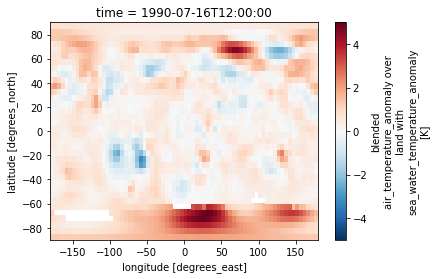

```python
HadCRUT['tas_mean'].sel(time='1990-07').plot()
```

**Use your knowledge of cartopy from previous days to plot the same figure with coastlines and other features**

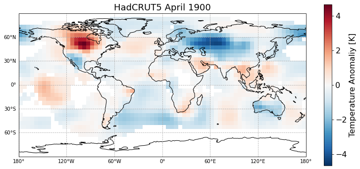

```python
#HadCRUT 1990-07 with coastlines
year_ = 1900
month_ = 4

#define the figure and axes
fig = plt.figure(figsize=[13,6]) #set the size of the figure
ax  = fig.add_subplot(projection = ccrs.PlateCarree(central_longitude=0))

#plot the datat on these axes
data_plotted = HadCRUT['tas_mean'].sel(time='{}-{}'.format(year_, str(month_).zfill(2))).plot(add_colorbar=False)

ax.coastlines(); #add coastlines
gl = ax.gridlines(draw_labels=True, linestyle='--'); #add grid lines
gl.xlabels_top = False #but don't show the top or right lat/lon labels
gl.ylabels_right = False

plt.title('HadCRUT5 {} {}'.format(month_names[month_-1], year_), fontsize=18); #make a title
cbar = fig.colorbar(data_plotted); #define a colorbar
cbar.ax.tick_params(labelsize=16); #define the colobar ticks
cbar.ax.set_ylabel('Temperature Anomaliy [K]', fontsize=16); #define the colorby label
```

# 2. Compute regional averages

## 2.1 Subset your data

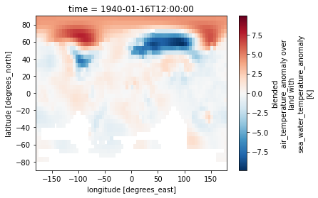

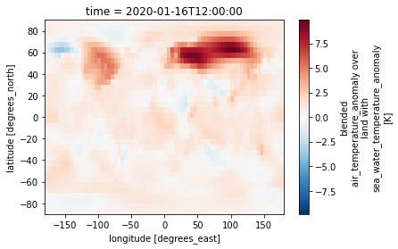

```python
month_ = 1 #select which month you're interested in
start_yr = 1940
end_yr   = 2020

#now select data for a reduced time period
month_HadCRUT = HadCRUT['tas_mean'].sel(time=HadCRUT['time.month']==month_).sel(time=slice(str(start_yr),str(end_yr)))

#plot the start and end years to make sure you've got the correct month (look at the title of the plots)
month_HadCRUT.sel(time=str(start_yr)).plot()
#See what happens if you comment out the next line (it should make a messy figure!)
plt.figure() #N.B if you want to make multiple plots in the same cell, make a new matplotlib figure instance.
month_HadCRUT.sel(time=str(end_yr)).plot(); #it's much cleaner to use the ; symbol after your last matplotlib command to stop text being printed
```

**We can see that the data is complete in the northern hemisphere back to at least 1950 for all grid cells**  
**Now we'll define 3 regions and plot the average temperature anomalies over the region - without weighting the grid cells**

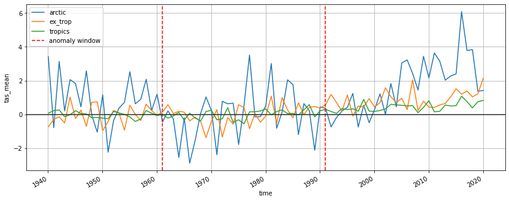

```python
#Define a list of regions
region_list = ['arctic', 'ex_trop', 'tropics']

#Define a dictionary of latitude min and max for each region
lat_lim = {} #initialize a dictionary
lat_lim['arctic'] = [66.6,90] #the minimum and maximum latitude for that region
lat_lim['ex_trop'] = [23.5,66.6]
lat_lim['tropics'] = [-23.5,23.5]

#Compte the spatial mean. What is wrong with doing this? We are weighting all the grid cells equally
region_sum = {} #initialize a dictionary
for region in region_list:
    region_sum[region] = month_HadCRUT.sel(latitude=slice(lat_lim[region][0],lat_lim[region][1])).mean('longitude').mean('latitude')


#Plot the data you've made
plt.figure(figsize=[14,5]) #initialize a new figure instance of matplotlib

for region in region_list:
    region_sum[region].plot(label=region) #include the label so the legend can pick it up

#plot vertical lines at 1961 and 1990 which are the edges of the averaging period used to calculate the anomalies
#N.B. our dataset uses 'datetime64[ns]' times so we can't just plot the line at 1961 and 1990 - those years have to be in a time format
plt.axvline(datetime.datetime(1961,1,1), c='r', linestyle='--', label='anomaly window')
plt.axvline(np.datetime64('1990-12-31'), c='r', linestyle='--') #Note this takes np.datetime64 and the previous line took a datetime object

plt.grid() #plot grid lines
plt.axhline(0, c='0.2') #plot the 0 line
plt.legend(); #plot the legend, include ';' to stop text being printed
```

## 2.2 Weighting with `cdo gridarea` (Linux)

**The problem with doing what we have just done is that each of the grid cells are not weighted equally, especially in the Arctic**  
**This means that we need to find out the size of each of the grid cells and weight them**  
**We can do this by using the linux command** `cdo gridarea <infile> <outfile>` **as below. Documentation can be found [here](https://code.mpimet.mpg.de/projects/cdo/embedded/cdo.pdf)**  
*Note you'll get a warning due to the variable `realization`, it's issues like this why we dropped this variable earlier (but we didn't update the netcdf file)*

```python
!cdo gridarea HadCRUT.5.0.1.0.analysis.anomalies.ensemble_mean.nc HadCRUT_weights.nc
```

```
Warning (cdfInqContents): Coordinates variable realization can't be assigned!
cdo    gridarea:                        1 1 1 1 1 1 1 1 1 1 2 2 2 2 2 2 2 2 2 2 3 3 3 3 3 3 3 3 3 3 4 4 4 4 4 4 4 4 4 4 5 5 5 5 5 5 5 5 5 5 6 6 6 6 6 6 6 6 6 6 7 7 7 7 7 7 7 7 7 7 8 8 8 8 8 8 8 8 8 8 9 9 9 9 9 9 9 9 9 91cdo    gridarea: Processed 1 variable [0.02s 9656KB].
```

**Now let's open up the grid cell area file and plot it, note the colorbar label tells you the units - we could also find this out by using** `ncdump` **or looking at the xarray variables as** `cdo` **provides coordinate labels**

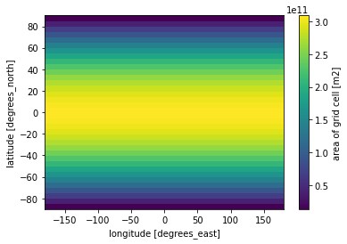

```python
weights = xr.open_dataset('HadCRUT_weights.nc')
weights['cell_area'].plot();
```

**Let's try creating regional averages again, but this time we'll weight each of the regions' grid cells properly**

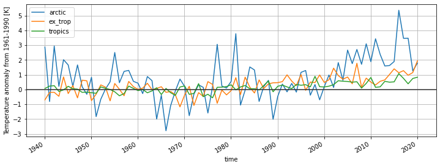

```python
weighted_sums = {}
for region in region_list: #loop through the 3 regions

    #select the grid cell areas for the latitudes required for that region
    weights_lat_slice = weights['cell_area'].sel(latitude=slice(lat_lim[region][0],lat_lim[region][1]))
    #normalize this by dividing by the sum of all the grid cell areas in that region
    weight_region = weights_lat_slice/weights_lat_slice.sum()

    #now we can multiply the anomaly data (within the correct region) with the weights we just calculated
    weighted_grid_cells = month_HadCRUT.sel(latitude=slice(lat_lim[region][0],lat_lim[region][1])) * weight_region
    #sum across the latitude and longitude (but not time) to get a 2D aray of temperature anomaly and time
    weighted_sums[region] = weighted_grid_cells.sum('latitude').sum('longitude')

#plot the data you've made
fig = plt.figure(figsize=[12,4]) #initialize a new figure instance of matplotlib

for region in region_list: #loop through all 3 regions again
    weighted_sums[region].plot(label=region) #include the label so the legend can pick it up

plt.grid() #plot grid lines
plt.axhline(0, c='0.2') #plot the 0 line
plt.legend(); #plot the legend, include ';' to stop text being printed
plt.ylabel('Temperature anomaly from 1961-1990 [K]'); #we don't have automatic labels as we have multuplied the data
```

**Now we've labeled the figure above as** `fig` **we can now call this and the plot will appear, this can also be uesful for saving with** `fig.savefig(<file/path.png>)` **Try plotting this figure again in a new cell, and then saving it**  
N.B. to save the figure without cutting off any of the axes you may need to invoke `fig.tight_layout()`

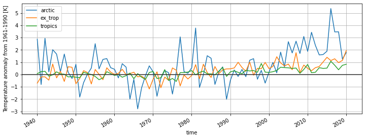

```python
fig
```

```python
fig.tight_layout() #if you don't include this you'll find the 'time' x-axis label is cut off
fig.savefig('Regional_T_anomalies_1940_2020_NH.png',dpi=150)
```

**Let's see what difference that weighting did**

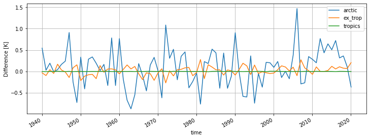

```python
plt.figure(figsize=[12,4]) #initialize a new figure instance of matplotlib

#plot the difference weighting makes
for region in region_list:
    (region_sum[region]-weighted_sums[region]).plot(label=region) #include the label so the legend can pick it up

plt.ylabel('Difference [K]')
plt.grid()
plt.legend();
```